# Práctica 2. Interacciones biológicas con **datos de poblaciones**

Ecología II — Unidad 2 (Competencia LV · Depredador–Presa LV)

UASD · Arlen Marmolejo Hernández

2025-09-26

> Donde quiera que veas el botón `Show`/`Hide`, haz clic para expandir/colapsar la caja de código.

```r
# ESTA ES UNA CAJA DE CÓDIGO DE EJEMPLO
```

# 1 **Competencia interespecífica** con el modelo de **Lotka–Volterra**

> Objetivo: evaluar el tipo de competencia LV entre dos especies a partir de una tabla pequeña (10 filas) de datos simulados y sus parámetros asociados, trabajando **a mano** o con ayuda de una hoja de cálculo, y R (opcionalmente).

## 1.1 Marco teórico — **Competencia interespecífica** con el modelo de **Lotka–Volterra**

**Fuente base**: *LibreTexts* — *15.5: Quantifying Competition Using the Lotka-Volterra Model* (Gettysburg College, Ecology for All).

### 1.1.1 Del **logístico** de una especie a la competencia de **dos especies**

Partimos del crecimiento **logístico** para cada especie en ausencia de la otra (intraespecífica):

$$\frac{d N_{1}}{dt}=r_{1} N_{1}\left(\frac{K_{1}-N_{1}}{K_{1}}\right),\qquad
\frac{d N_{2}}{dt}=r_{2} N_{2}\left(\frac{K_{2}-N_{2}}{K_{2}}\right).$$

Para incorporar **competencia interespecífica**, suponemos que individuos de la especie 2 reducen el crecimiento de la 1 en **unidades equivalentes** a $\alpha_{12}$ individuos de 1 (y viceversa $\alpha_{21}$). Esto produce las **ecuaciones de Lotka–Volterra (competencia)**:

$$\frac{dN_{1}}{dt}= r_{1}N_{1}\!\left(\frac{K_1 - N_{1} - \alpha_{12}N_{2}}{K_{1}}\right),\qquad
\frac{dN_{2}}{dt}= r_{2}N_{2}\!\left(\frac{K_2 - N_{2}-\alpha_{21}N_{1}}{K_{2}}\right).$$

> $\alpha_{12}$ y $\alpha_{21}$ son **coeficientes de competencia** (adimensionales): convierten individuos de una especie en “**equivalentes**” de la otra en términos de uso de recursos.

**Más información Ocultar**

Sobre el modelo logístico, construimos el modelo con competencia. Para ello, incorporamos la competencia interespecífica en cada una de estas ecuaciones. Suponemos que cada nuevo integrante de la Población 1 reduce los recursos disponibles para cada integrante de la Población 2 y, por lo tanto, disminuye su tasa de crecimiento poblacional. Del mismo modo, los nuevos integrantes de la Población 2 también reducirán los recursos disponibles para los miembros de la Población 1; eso es, en esencia, lo que significa competencia interespecífica.

La forma más simple de modelar esto sería modificar el término correspondiente al efecto de la densidad. Sin embargo, esa opción supone que cada individuo adicional de la Población 2 afecta a la Población 1 exactamente igual que lo haría un individuo adicional de la propia Población 1. Como esto no tiene por qué ser cierto, introducimos un **coeficiente de competencia** que expresa cuánto influye, en términos relativos, cada individuo adicional de la Población 2 sobre la Población 1 (comparado con el efecto de un individuo adicional de la Población 1). El modelo para la Población 2 se modifica de manera paralela. El resultado es el modelo de Lotka–Volterra para competencia entre dos especies.

Observa los subíndices de los coeficientes de competencia: el que va “de 2 a 1” expresa el efecto de un miembro de la Población 2 sobre la tasa de crecimiento de la Población 1; el que va “de 1 a 2” expresa el efecto de un miembro de la Población 1 sobre la tasa de crecimiento de la Población 2.

El valor del coeficiente de competencia nos dice algo sobre la importancia relativa de la competencia **interespecífica** frente a la **intraespecífica** en la dinámica de una especie:

- Si el coeficiente es **menor que 1**, la competencia **intraespecífica** tiene un impacto per cápita más fuerte en la disponibilidad de recursos para esa especie.
- Si el coeficiente es **mayor que 1**, la competencia **interespecífica** tiene un impacto per cápita más fuerte.
- Si el coeficiente es **igual a 1**, ambos tipos de competencia tienen un impacto per cápita similar sobre la disponibilidad de recursos para esa especie.

### 1.1.2 **Isoclinas** (líneas de crecimiento cero) y **puntos de equilibrio**

La isoclina de 1 ($dN_1/dt=0$) cumple $N_{1}+\alpha_{12}N_{2}=K_{1}$.  
La de 2 ($dN_2/dt=0$) cumple $N_{2}+\alpha_{21}N_{1}=K_{2}$.

**Lectura visual** del plano $N_1$–$N_2$: debajo de la isoclina de una especie esa especie **crece** ($dN_i/dt>0$); por encima **disminuye**. Si las flechas del campo apuntan hacia el cruce, hay **coexistencia estable**; si “caen” a un **eje**, hay **exclusión** (extinción local de una especie).

> **Figuras (del repo)**

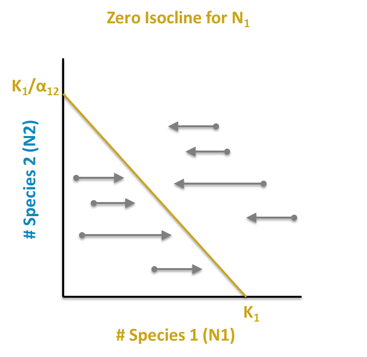

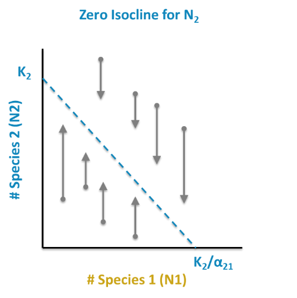

[figure not shown]

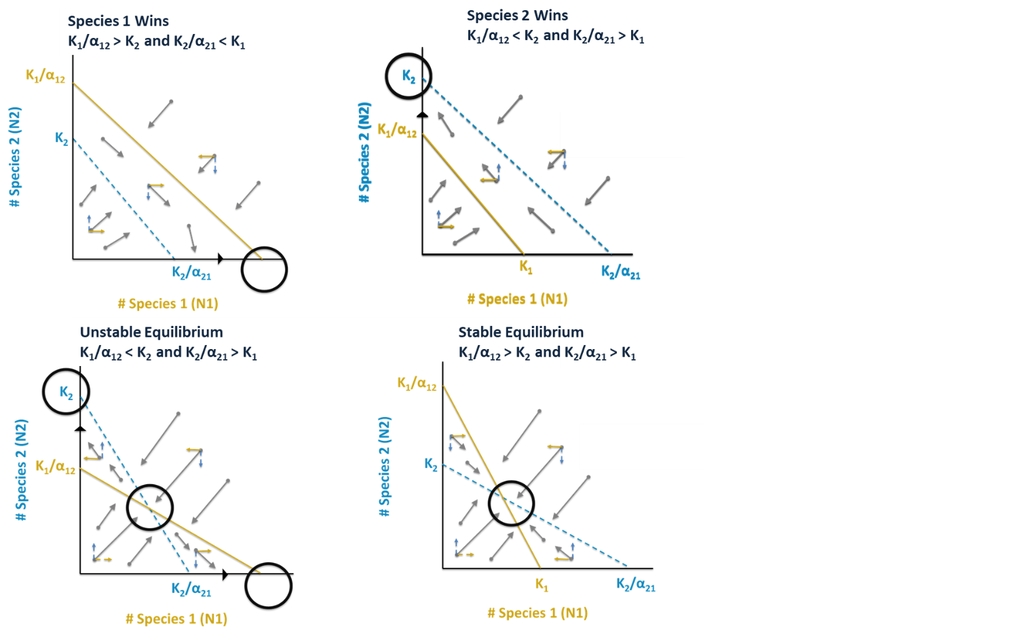

### 1.1.3 Trayectoria

> **Referencia**: basadas en LibreTexts 15.5 (ver sección **Referencias**).

## 1.2 Práctica — **Competencia LV** con datos **pequeños** por estudiante

> **Importante**: Cada estudiante trabaja el **mismo mandato** pero con **datos distintos** y **pequeños** (10 filas) para poder **hacerlo a mano**. Se generan a partir de un **pseudónimo** (“Est01”, “Est02”, …).

### 1.2.1 Preparación y **pseudónimo**

Copia y pega este código en RStudio y ejecútalo (para ver el código haz clic en `Show`).

```r
# Paquetes usados
suppressPackageStartupMessages({
  library(ggplot2)
  library(digest)
})

# Lista ejemplo (puedes sustituir por la de clase)
if (!exists("pseudonimos_clase")){
  pseudonimos_clase <- paste0("Est", sprintf("%02d", 1:30))
}
```

Esta es la lista de pseudónimos.

```r
cat("Pseudónimos: ", paste(pseudonimos_clase[-1], collapse=", "), "\n")
```

Pseudónimos: Est02, Est03, Est04, Est05, Est06, Est07, Est08, Est09, Est10, Est11, Est12, Est13, Est14, Est15, Est16, Est17, Est18, Est19, Est20, Est21, Est22, Est23, Est24, Est25, Est26, Est27, Est28, Est29, Est30

En el código siguiente, cambia la cadena de caracteres “Est01” por tu pseudónimo (p. ej. “Est05”). Esto genera tus datos **únicos** y **reproducibles**. Anuncia tu elección en el foro.

```r
# Elige tu pseudónimo
MI_PSEUDONIMO <- "Est01"  # <-- CAMBIA AQUÍ
```

### 1.2.2 Generador de datos **reproducibles**

Este es el código que genera la tabla de datos (10 filas) y los parámetros para trabajar **a mano**. Recuerda que para que este código produzca tus datos, debes haber ejecutado el bloque anterior con tu pseudónimo.

```r
seed_from_name <- function(x){
  # hash a 32 bits reproducible
  hx <- tryCatch(digest::digest(x, algo="xxhash64", serialize=FALSE),
                 error=function(e) digest::digest(x, algo="crc32", serialize=FALSE))
  by <- vapply(seq(1, 8, 2), function(i) strtoi(substr(hx, i, i+1), 16L), numeric(1))
  u32 <- sum(by * c(1,256,65536,16777216))
  as.integer(1 + (u32 %% (.Machine$integer.max - 1)))
}

# Generador competencia LV con tabla pequeña (~10 filas) para trazo a mano
gen_competencia_lv <- function(seed, steps_small=10, steps_traj=300, dt=0.05){
  set.seed(seed + 501)
  K1 <- sample(seq(320, 680, by=20), 1)
  K2 <- sample(seq(280, 640, by=20), 1)
  r1 <- runif(1, 0.35, 0.9)
  r2 <- runif(1, 0.35, 0.9)
  a12 <- runif(1, 0.2, 1.1)
  a21 <- runif(1, 0.2, 1.1)

  # Forzar 4 escenarios variados según semilla
  caso <- (seed %% 4) + 1
  if (caso == 1){ a12 <- max(0.2, a12 * 0.8); a21 <- min(1.1, a21 * 1.2) }      # 1 excluye 2
  if (caso == 2){ a12 <- min(1.1, a12 * 1.2); a21 <- max(0.2, a21 * 0.8) }      # 2 excluye 1
  if (caso == 3){ a12 <- a12 * 0.95; a21 <- a21 * 0.95 }                         # coexistencia estable
  if (caso == 4){ a12 <- a12 * 1.05; a21 <- a21 * 1.05 }                         # coexistencia inestable

  euler <- function(N10,N20,steps,dt){
    N1 <- N2 <- numeric(steps); N1[1] <- N10; N2[1] <- N20
    for (t in 2:steps){
      dN1 <- r1*N1[t-1]*(1 - (N1[t-1] + a12*N2[t-1])/K1)
      dN2 <- r2*N2[t-1]*(1 - (N2[t-1] + a21*N1[t-1])/K2)
      N1[t] <- max(0, N1[t-1] + dN1*dt)
      N2[t] <- max(0, N2[t-1] + dN2*dt)
    }
    data.frame(t = 0:(steps-1)*dt, N1=N1, N2=N2)
  }

  N10 <- round(runif(1, 0.15, 0.85)*K1)
  N20 <- round(runif(1, 0.15, 0.85)*K2)
  traj <- euler(N10, N20, steps_traj, dt)

  # Submuestreo para tabla pequeña (10 puntos) y redondeo “a mano”
  take <- unique(round(seq(1, nrow(traj), length.out = steps_small)))
  small <- traj[take, c("t","N1","N2")]
  rnd5 <- function(x) 5*round(x/5)
  small$N1 <- rnd5(small$N1); small$N2 <- rnd5(small$N2)

  pars <- c(r1=r1,r2=r2,K1=K1,K2=K2,a12=a12,a21=a21,caso=caso,N10=N10,N20=N20)
  list(data_traj=traj, data_small=small, pars=pars)
}

SEED <- seed_from_name(MI_PSEUDONIMO)
comp <- gen_competencia_lv(SEED)
```

### 1.2.3 **Tabla y parámetros**

```r
knitr::kable(comp$data_small, row.names = F,
             caption="Competencia LV — tabla de 10 filas para realizar tu ejercicio a mano. El código original produce la tabla del Est01. Recuerda que para que este código produzca tu tabla, debes haber elegido y ejecutado el bloque correspondiente con tu pseudónimo.")
```

Table 1.1: Competencia LV — tabla de 10 filas para realizar tu ejercicio a mano. El código original produce la tabla del Est01. Recuerda que para que este código produzca tu tabla, debes haber elegido y ejecutado el bloque correspondiente con tu pseudónimo.

| t | N1 | N2 |
| --- | --- | --- |
| 0.00 | 325 | 365 |
| 1.65 | 275 | 355 |
| 3.30 | 255 | 365 |
| 5.00 | 240 | 380 |
| 6.65 | 230 | 390 |
| 8.30 | 225 | 400 |
| 9.95 | 220 | 405 |
| 11.65 | 215 | 415 |
| 13.30 | 210 | 415 |
| 14.95 | 205 | 420 |

```r
knitr::kable(as.data.frame(comp$pars),
             caption="Competencia LV — parámetros. El código original produce la tabla del Est01. Recuerda que para que este código produzca tu tabla, debes haber elegido y ejecutado el bloque correspondiente con tu pseudónimo.",
             col.names=c("Parámetro","Valor"))
```

Table 1.1: Competencia LV — parámetros. El código original produce la tabla del Est01. Recuerda que para que este código produzca tu tabla, debes haber elegido y ejecutado el bloque correspondiente con tu pseudónimo.

| Parámetro | Valor |
| --- | --- |
| r1 | 0.7362978 |
| r2 | 0.8315835 |
| K1 | 420.0000000 |
| K2 | 620.0000000 |
| a12 | 0.5178140 |
| a21 | 0.9469748 |
| caso | 3.0000000 |
| N10 | 327.0000000 |
| N20 | 366.0000000 |

### 1.2.5 **Demostración manual, usando datos de *Est01***

**Parámetros de *Est01*** $r_1=0.7363,\; r_2=0.8316,\; K_1=420,\; K_2=620,\; \alpha_{12}=0.517814,\; \alpha_{21}=0.9469748$

#### 1.2.5.1 **Calcula los interceptos** de las isoclinas (anota a 1 decimal)

Modelo LV de competencia:

$$\frac{dN_1}{dt}=r_1N_1\!\left(\frac{K_1 - N_1 - \alpha_{12}N_2}{K_1}\right),\qquad
\frac{dN_2}{dt}=r_2N_2\!\left(\frac{K_2 - N_2 - \alpha_{21}N_1}{K_2}\right).$$

Isoclinas (líneas de crecimiento cero):

- **Isoclina de 1** ($dN_1/dt=0$): $N_1=K_1-\alpha_{12}N_2$ Interceptos: $(K_1,0)=(\mathbf{420.0},0)$ y $(0,K_1/\alpha_{12})=(0,\mathbf{811.1})$ (cálculo: $420/0.517814=811.102\rightarrow \mathbf{811.1}$)
- **Isoclina de 2** ($dN_2/dt=0$): $N_2=K_2-\alpha_{21}N_1$ Interceptos: $(0,K_2)=(0,\mathbf{620.0})$ y $(K_2/\alpha_{21},0)=(\mathbf{654.7},0)$ (cálculo: $620/0.9469748=654.716\rightarrow \mathbf{654.7}$)

**En Excel (opcional):** con celdas `K1=420`, `K2=620`, `a12=0.517814`, `a21=0.9469748` `=K1/a12` → **811.1**; `=K2/a21` → **654.7**.

#### 1.2.5.2 **Fija escalas de ejes** para que entren todos los interceptos

Usa límites algo superiores al mayor intercepto de cada eje:

- Horizontal $x_{\max}\approx 1.1\times \max(K_1,\;K_2/\alpha_{21})=1.1\times 654.7\approx \mathbf{720}$.
- Vertical $y_{\max}\approx 1.1\times \max(K_2,\;K_1/\alpha_{12})=1.1\times 811.1\approx \mathbf{900}$.

Traza ejes $N_1$ (0…720) y $N_2$ (0…900). Rejilla cómoda: pasos de 50.

#### 1.2.5.3 **Dibuja las isoclinas** con regla (o con Dispersión en Excel)

- **Isoclina N1** (**sólida**, p.ej. naranja): une $(\mathbf{420},0)$ con $(0,\mathbf{811.1})$. Etiqueta: *Isoclina N1 (dN1/dt = 0)*.
- **Isoclina N2** (**punteada**, p.ej. azul): une $(0,\mathbf{620})$ con $(\mathbf{654.7},0)$. Etiqueta: *Isoclina N2 (dN2/dt = 0)*.

**En Excel:** crea dos series con esos dos puntos por línea → Gráfico de **Dispersión con líneas**. Formatea N1 **sólida** y N2 **discontinua**.

#### 1.2.5.4 **Sombréa las 4 regiones** por signos de $(dN_1/dt,\ dN_2/dt)$

Regla memotécnica: **debajo** de una isoclina esa especie **crece**; **encima**, **disminuye**.

- Debajo de ambas → **`++`** (suben 1 y 2).
- Debajo de N1 y **encima** de N2 → **`+-`** (1 sube, 2 baja).
- **Encima** de N1 y debajo de N2 → **`-+`** (1 baja, 2 sube).
- Encima de ambas → **`--`** (bajan 1 y 2).

Sombrea suavemente o escribe los símbolos en cada zona.

#### 1.2.5.5 **Traza tu trayectoria** con la **tabla pequeña** de Est01

Tus 10 puntos $(N_1,N_2)$:

$$(325,365)\to(275,355)\to(255,365)\to\cdots\to(205,420)$$

Colócalos en orden de $t$ y **únelos con flechas** para indicar el sentido temporal.

#### 1.2.5.6 **Verificación numérica “a mano”** del **signo** en 4 puntos

Evalúa el paréntesis de cada derivada (no necesitas los valores exactos):

$$dN_1/dt\propto\Big(1-\frac{N_1+\alpha_{12}N_2}{K_1}\Big),\qquad
dN_2/dt\propto\Big(1-\frac{N_2+\alpha_{21}N_1}{K_2}\Big).$$

Ejemplos con *Est01* ($\alpha_{12}=0.517814,\ \alpha_{21}=0.9469748,\ K_1=420,\ K_2=620$):

- **`++`** en $(100,100)$: $100+0.5178\cdot100=151.8<420\Rightarrow dN_1>0$; $100+0.9470\cdot100=194.7<620\Rightarrow dN_2>0$.
- **`+-`** en $(100,540)$: $100+0.5178\cdot540=379.6<420\Rightarrow dN_1>0$; $540+0.9470\cdot100=634.7>620\Rightarrow dN_2<0$.
- **`-+`** en $(400,100)$: $400+0.5178\cdot100=451.8>420\Rightarrow dN_1<0$; $100+0.9470\cdot400=478.8<620\Rightarrow dN_2>0$.
- **`--`** en $(500,600)$: $500+0.5178\cdot600=810.7>420\Rightarrow dN_1<0$; $600+0.9470\cdot500=1073.5>620\Rightarrow dN_2<0$.

#### 1.2.5.7 **Diagnóstico por interceptos** (casos clásicos) con números de Est01

Compara:

- $K_1\stackrel{?}{>}K_2/\alpha_{21}$ → $420\stackrel{?}{>}654.7$ → **FALSO**.
- $K_1/\alpha_{12}\stackrel{?}{>}K_2$ → $811.1\stackrel{?}{>}620$ → **VERDADERO**.

*(Opcional)* Cruce de isoclinas (equilibrio interior):

$$N_1^*=\frac{K_1-\alpha_{12}K_2}{1-\alpha_{12}\alpha_{21}}=\mathbf{194.2},\quad
N_2^*=\frac{K_2-\alpha_{21}K_1}{1-\alpha_{12}\alpha_{21}}=\mathbf{436.1}$$

### 1.2.6 **Demostración con R usando datos de *Est01*** (puedes aplicarlo a tu caso también)

```r
pars <- comp$pars
K1 <- pars["K1"]; K2 <- pars["K2"]; a12 <- pars["a12"]; a21 <- pars["a21"]; r1 <- pars["r1"]; r2 <- pars["r2"]

int_N1_x <- K1/a12
int_N1_y <- K1
int_N2_x <- K2/a21
int_N2_y <- K2

cat(sprintf("Interceptos calculados:\n  Isoclina N1: (0, %.1f) y (%.1f, 0)\n  Isoclina N2: (0, %.1f) y (%.1f, 0)\n",
            int_N1_y, int_N1_x, int_N2_y, int_N2_x))
```

```r
# Diagnóstico por desigualdades (teórico)
c1 <- (K1 >  K2 / a21) && (K1 / a12 > K2)
c2 <- (K1 <  K2 / a21) && (K1 / a12 < K2)
c3 <- (K1 >  K2 / a21) && (K2 >  K1 / a12)
c4 <- (K1 <  K2 / a21) && (K2 <  K1 / a12)
diag <- if (c1) "1 excluye 2" else if (c2) "2 excluye 1" else if (c3) "coexistencia estable" else if (c4) "coexistencia inestable" else "indeterminado"
cat("Diagnóstico teórico por interceptos:", diag, "\n")
```

### 1.2.7 Gráfico interpretativo (**sombras + flechas + trayectoria**)

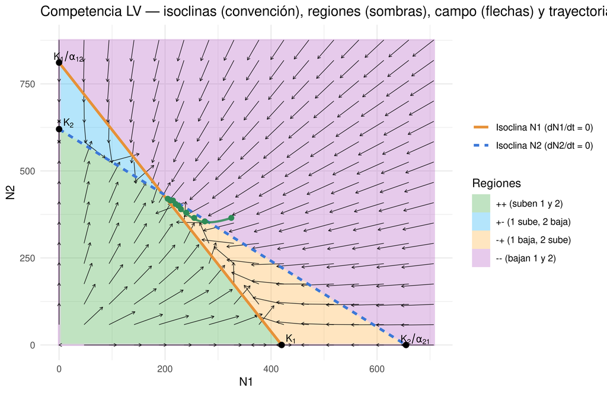

```r
# --- Interceptos correctos y límites adecuados ---

# Interceptos por isoclina
# N1-iso: N1 = K1 - a12*N2  ->  (x = K1, y = 0) y (x = 0, y = K1/a12)
xint_N1iso <- K1
yint_N1iso <- K1 / a12

# N2-iso: N2 = K2 - a21*N1 ->  (x = K2/a21, y = 0) y (x = 0, y = K2)
xint_N2iso <- K2 / a21
yint_N2iso <- K2

# Límites que siempre muestren TODOS los interceptos
x_max <- 1.08 * max(xint_N1iso, xint_N2iso, na.rm = TRUE)
y_max <- 1.08 * max(yint_N1iso, yint_N2iso, na.rm = TRUE)

# Malla para sombreado de regiones por signos
nx <- 160; ny <- 160
grid <- expand.grid(N1 = seq(0, x_max, length.out = nx),
                    N2 = seq(0, y_max, length.out = ny))
grid$dN1 <- r1*grid$N1*(1 - (grid$N1 + a12*grid$N2)/K1)
grid$dN2 <- r2*grid$N2*(1 - (grid$N2 + a21*grid$N1)/K2)
grid$region <- with(grid,
  ifelse(dN1>0 & dN2>0, "++ (suben 1 y 2)",
  ifelse(dN1>0 & dN2<0, "+- (1 sube, 2 baja)",
  ifelse(dN1<0 & dN2>0, "-+ (1 baja, 2 sube)",
                     "-- (bajan 1 y 2)"))))
grid$region <- factor(grid$region,
  levels = c("++ (suben 1 y 2)","+- (1 sube, 2 baja)",
             "-+ (1 baja, 2 sube)","-- (bajan 1 y 2)"))

# Campo de vectores (flechas)
gd <- expand.grid(N1 = seq(0, x_max, length.out = 16),
                  N2 = seq(0, y_max, length.out = 16))
gd$dN1 <- r1*gd$N1*(1 - (gd$N1 + a12*gd$N2)/K1)
gd$dN2 <- r2*gd$N2*(1 - (gd$N2 + a21*gd$N1)/K2)
L <- sqrt(gd$dN1^2 + gd$dN2^2); L[L==0] <- 1e-9
gd$u1 <- gd$dN1/L; gd$u2 <- gd$dN2/L
arrow_len <- 0.07 * max(x_max, y_max)
gd$xend <- gd$N1 + arrow_len*gd$u1
gd$yend <- gd$N2 + arrow_len*gd$u2

# Isoclinas trazadas SOLO entre sus interceptos
# N2-iso: variar N1 de 0 a xint_N2iso
n1_seg <- seq(0, xint_N2iso, length.out = 500)
n2_iso <- K2 - a21*n1_seg

# N1-iso: variar N2 de 0 a yint_N1iso
n2_seg <- seq(0, yint_N1iso, length.out = 500)
n1_iso <- K1 - a12*n2_seg

df_iso <- rbind(
  data.frame(N1 = n1_iso, N2 = n2_seg,
             iso = "Isoclina N1 (dN1/dt = 0)"),
  data.frame(N1 = n1_seg, N2 = n2_iso,
             iso = "Isoclina N2 (dN2/dt = 0)")
)

# Puntos y etiquetas de interceptos (en el eje correcto)
pts_iso <- data.frame(
  N1  = c(xint_N1iso, 0,            0,           xint_N2iso),
  N2  = c(0,          yint_N1iso,   yint_N2iso,  0),
  lab = c("K[1]", "K[1]/alpha[12]", "K[2]", "K[2]/alpha[21]")
)

# Gráfico
ggplot() +
  geom_raster(data = grid, aes(N1, N2, fill = region),
              alpha = 0.35, interpolate = TRUE) +
  scale_fill_manual(values = c("++ (suben 1 y 2)" = "#4CAF50",
                               "+- (1 sube, 2 baja)" = "#29B6F6",
                               "-+ (1 baja, 2 sube)" = "#FFB74D",
                               "-- (bajan 1 y 2)" = "#BA68C8"),
                    name = "Regiones") +
  geom_segment(data = gd, aes(x = N1, y = N2, xend = xend, yend = yend),
               arrow = arrow(length = grid::unit(3,"pt")),
               linewidth = 0.3, alpha = 0.8) +
  geom_path(data = df_iso, aes(N1, N2, color = iso, linetype = iso),
            linewidth = 1.2) +
  scale_color_manual(values = c("Isoclina N1 (dN1/dt = 0)" = "#E69138",  # naranja sólida
                                "Isoclina N2 (dN2/dt = 0)" = "#3C78D8"), # azul punteada
                     name = NULL) +
  scale_linetype_manual(values = c("Isoclina N1 (dN1/dt = 0)" = "solid",
                                   "Isoclina N2 (dN2/dt = 0)" = "22"),
                        name = NULL) +
  geom_point(data = pts_iso, aes(N1, N2), size = 2.2) +
  geom_text(data = pts_iso, aes(N1, N2, label = lab), parse = TRUE,
            nudge_x = 0.02*max(x_max,y_max),
            nudge_y = 0.02*max(x_max,y_max),
            size = 3.3) +
  geom_point(data = comp$data_small, aes(N1, N2), color = "#2E8B57", size = 2) +
  geom_path (data = comp$data_traj,  aes(N1, N2), color = "#2E8B57",
             linewidth = 1.0, alpha = 0.85) +
  coord_cartesian(xlim = c(0, x_max), ylim = c(0, y_max), expand = TRUE) +
  labs(title = "Competencia LV — isoclinas (convención), regiones (sombras), campo (flechas) y trayectoria",
       x = "N1", y = "N2") +
  theme_minimal() +
  theme(legend.position = "right",
        legend.box.margin = margin(t = 2, r = 2, b = 2, l = 2))
```

> **Figuras complementarias (del repo)**

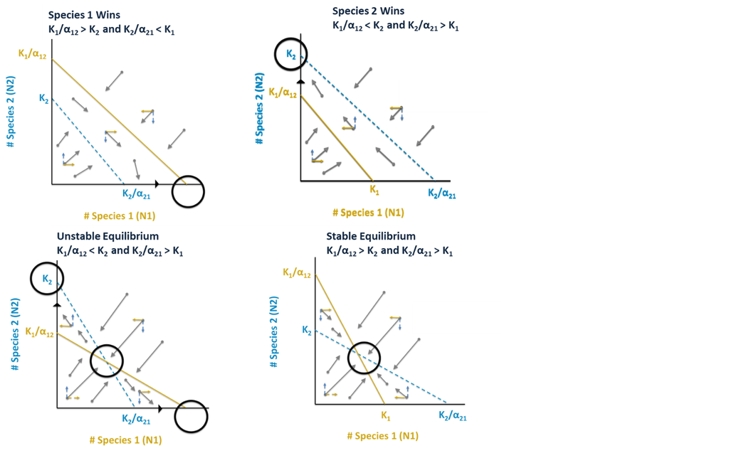

## 1.3 **Exclusión competitiva** — texto guía para interpretar

> **Definición operativa**: **exclusión competitiva** significa que, bajo condiciones constantes, **una especie reduce a la otra hasta densidad ≈ 0 en esa comunidad** (*extinción local*). Coloquialmente: “**1 saca a 2 del sitio**”. No implica extinción global; la especie excluida puede persistir en otro hábitat o volver por inmigración.

En el **modelo de Lotka–Volterra**:

- Decimos **“1 excluye a 2”** cuando la trayectoria termina en $(K_1,0)$: la población 2 cae al **eje $N_2=0$** y no se recupera.
- **Lectura del plano $N_1$–$N_2$**: si las **flechas** del campo llevan hacia el eje $N_2=0$, **2 se extingue localmente**; si llevan al eje $N_1=0$, la excluida es **1**; si llevan al **cruce de isoclinas**, hay **coexistencia**.

**Cuándo pasa**: cuando la **competencia interespecífica** sobre la especie perdedora es tan fuerte que su crecimiento es **negativo** frente a la otra, incluso a bajas densidades.  
**Cuándo no**: con **partición de nicho**, **variación ambiental**, **heterogeneidad espacial** o **rescate por inmigración**, la coexistencia puede mantenerse.

# 2 **Depredador–presa (LV)** — *con tus datos*

## 2.1 Datos

```r
# Depredador–presa LV: presa (N) y depredador (P)
gen_predpresa_lv <- function(seed, tmax=150, by=0.2){
  set.seed(seed + 602)
  r <- runif(1, 0.3, 1.1)
  a <- runif(1, 0.006, 0.02)
  b <- runif(1, 0.06, 0.2)
  m <- runif(1, 0.25, 0.9)
  N0 <- sample(20:80, 1)
  P0 <- sample(6:20, 1)
  pars <- c(r=r, a=a, b=b, m=m)
  tt <- seq(0, tmax, by=by)
  lv <- function(t, y, p){
    N <- y[1]; P <- y[2]
    with(as.list(p), {
      dN <- r*N - a*N*P
      dP <- b*a*N*P - m*P
      list(c(dN, dP))
    })
  }
  out <- as.data.frame(ode(y=c(N=N0, P=P0), times=tt, func=lv, parms=pars))
  pars2 <- c(pars, N0=N0, P0=P0, N_star=m/(b*a), P_star=r/a)
  list(data=out, pars=pars2)
}

# Construye datos para MI_PSEUDONIMO
pp   <- gen_predpresa_lv(SEED)
```

## 2.2 **A mano** (entregable)

1. Con tus parámetros $r,a,b,m$ calcula $N^*=\frac{m}{ba}$, $P^*=\frac{r}{a}$.
2. Dibuja las **nullclines** (líneas de crecimiento cero) en el plano $N$–$P$.
3. Señala la dirección cualitativa del campo de vectores en 4 regiones.

## 2.3 **En R**: series y plano de fase

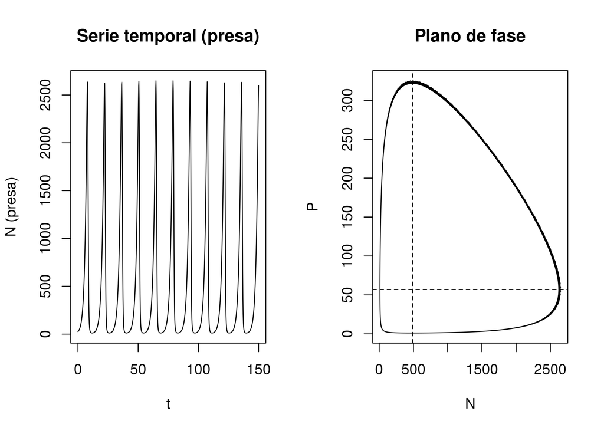

```r
pp_dat <- pp$data; pp_par <- pp$pars
Nstar <- pp_par["N_star"]; Pstar <- pp_par["P_star"]

par(mfrow=c(1,2))
plot(pp_dat$time, pp_dat$N, type="l", xlab="t", ylab="N (presa)", main="Serie temporal (presa)")
plot(pp_dat$N, pp_dat$P, type="l", xlab="N", ylab="P", main="Plano de fase")
abline(v = Nstar, h = Pstar, lty=2)
```

```r
par(mfrow=c(1,1))
pp_par[c("r","a","b","m","N_star","P_star")]
```

```
##            r            a            b            m       N_star       P_star
##   0.64442893   0.01133067   0.12625733   0.69500409 485.81962602  56.87472534
```

**Interpretación**: cómo cambian amplitudes/períodos cuando aumentan/disminuyen $a,b,m$; relación de fase (pico de $N$ precede a $P$).

# 3 Referencias

- *LibreTexts*: **15.5: Quantifying Competition Using the Lotka–Volterra Model** (Gettysburg College, *Ecology for All*). Licencia **CC BY-NC-SA**. URL: https://bio.libretexts.org/Courses/Gettysburg_College/01%3A_Ecology_for_All/15%3A_Competition/15.05%3A_Quantifying_Competition_Using_the_Lotka-Volterra_Model